# ANN_Task2_CNN

### Sudoku Digit Prediction - Task 2

The script merges strings from 81-row segments in a CSV, creating a new file with these merged strings.

```python
import pandas as pd

# Load the CSV file
file_path = '/content/new_sudoku_submission_output.csv'
df = pd.read_csv(file_path)

# Initialize an empty list to store the concatenated strings
concatenated_values = []

# Iterate over the DataFrame in chunks of 81 rows
for start in range(0, len(df), 81):
    end = start + 81
    chunk = df.iloc[start:end]
    concatenated_string = ''.join(map(str, chunk['value'].values))
    concatenated_values.append(concatenated_string)

# Create a new DataFrame with the concatenated strings
new_df = pd.DataFrame(concatenated_values, columns=['Concatenated Values'])

# Save the new DataFrame to a CSV file
new_file_path = 'Train Labels concatenated_values.csv'
new_df.to_csv(new_file_path, index=False)

print(f"File saved as {new_file_path}")
```

```
File saved as Train Labels concatenated_values.csv
```

The code combines specific columns from two CSV files into one, saving the result in a new CSV.

```python
import pandas as pd

# File paths
file1 = '/content/new_sudoku_submission_input.csv'
file2 = '/content/new_sudoku_submission_output.csv'
output_file = '/content/concatenated_data.csv'
# Load data from CSV files
df1 = pd.read_csv(file1, usecols=[0], header=None)
df2 = pd.read_csv(file2, usecols=[0], header=None)


df1.columns = ['Quiz']
df2.columns = ['Solution']

# Concatenate the two DataFrames horizontally
combined_df = pd.concat([df1, df2], axis=1)

combined_df.to_csv(output_file, index=False)

print(f"Combined data saved to {output_file}")
```

```
Combined data saved to /content/concatenated_data.csv
```

```python
import torch
from torch.utils.data import Dataset, DataLoader
import pandas as pd
import numpy as np

data = pd.read_csv(r"/content/new_concatinated_traindata.csv")
data
```

|  | Quiz | Solution |
| --- | --- | --- |
| 0 | 0832954170018000590950008620700009000000700203... | 6832954174218673597953418625721349868465791233... |
| 1 | 1007540320002060070048390500010780000405903800... | 1697548323582169472748396515314782967465923189... |
| 2 | 7000508398000230409300782002798004000004970266... | 7126548398659237419341782652798614533584971266... |
| 3 | 0000930078030000290590824039003502016008007081... | 2145936878637415297596824139783542616351297481... |
| 4 | 6507300904986000070370002560003456020000080742... | 6527348911986524374371982569713456823852619742... |
| ... | ... | ... |
| 49995 | 0896000576200001000408102060107098239020800000... | 1896243576279351845438172964167598239724835613... |
| 49996 | 7413090080050800402300000708000360276570481903... | 7413592689657823412386149757895364276572481933... |
| 49997 | 2004639108040080000800057034200070000008064919... | 2574639181347986256892157434219573863758264919... |
| 49998 | 9082000000024609706748000507000193800000025003... | 9382571461524639786748912537256193844693825173... |
| 49999 | 7864239050240080000390060200026800730970040004... | 7164239855247983168391567241526894733972145654... |

50000 rows × 2 columns

```python
import torch

# Check if GPU is available and set the device accordingly
device = torch.device("cuda" if torch.cuda.is_available() else "cpu")
print("Using device:", device)
```

```
Using device: cuda
```

### Data Preprocessing and Creating DataLoaders

- Splits a DataFrame into training (80%) and validation (20%) sets.
- Converts Sudoku puzzles and solutions into tensors within the `prepare_dataset` function:
  - Puzzles are normalized and reshaped to 1x9x9 tensors.
  - Solutions are adjusted for zero-based indexing (for training data).
- Creates `TensorDataset` objects for both training and validation data.
- Initializes `DataLoader` instances for each dataset with specified batch sizes (640) and shuffle settings (true for training, false for validation).

```python
from torch.utils.data import TensorDataset, DataLoader
import torch
import pandas as pd

train_idx = int(len(data) * 0.80)

# Split the data into training and validation sets
train_df = data.iloc[:train_idx]
val_df = data.iloc[train_idx:]

def prepare_dataset(df, subset="train"):
    puzzles = []
    solutions = []

    for idx in range(len(df)):
        puzzle = df.iloc[idx, 0]
        solution = df.iloc[idx, 1]

        puzzle_tensor = torch.tensor([int(p) for p in puzzle], dtype=torch.float32).view(1, 9, 9) / 9 - 0.5
        puzzles.append(puzzle_tensor)

        if subset == 'train':
            solution_tensor = torch.tensor([max(int(s) - 1, 0) for s in solution], dtype=torch.int64).view(-1)
            solutions.append(solution_tensor)

    puzzles_tensor = torch.stack(puzzles)

    if subset == 'train':
        solutions_tensor = torch.stack(solutions)
        return TensorDataset(puzzles_tensor, solutions_tensor)

    return TensorDataset(puzzles_tensor)

# Prepare the training and validation datasets
train_dataset = prepare_dataset(train_df, subset="train")
val_dataset = prepare_dataset(val_df, subset="train")

# Create DataLoaders
train_loader = DataLoader(train_dataset, batch_size=640, shuffle=True)
val_loader = DataLoader(val_dataset, batch_size=640, shuffle=False)
```

### Defining Model

```python
import torch.nn as nn
import torch.nn.functional as F


class SudokuSolver(nn.Module):
    def __init__(self):
        super(SudokuSolver, self).__init__()
        self.conv1 = nn.Conv2d(1, 64, kernel_size=3, padding=1)
        self.bn1 = nn.BatchNorm2d(64)
        self.conv2 = nn.Conv2d(64, 128, kernel_size=3, padding=1)
        self.bn2 = nn.BatchNorm2d(128)
        self.conv3 = nn.Conv2d(128, 256, kernel_size=3, padding=1)
        self.bn3 = nn.BatchNorm2d(256)
        self.conv4 = nn.Conv2d(256, 256, kernel_size=1)
        self.fc1 = nn.Linear(256 * 9 * 9, 81 * 9)
        self.dropout1 = nn.Dropout(0.8)
    def forward(self, x):
        x = F.relu(self.bn1(self.conv1(x)))
        x = F.relu(self.bn2(self.conv2(x)))
        x = F.relu(self.bn3(self.conv3(x)))
        x = F.relu(self.conv4(x))
        x = x.view(x.size(0), -1)
        x = self.dropout1(x)
        x = self.fc1(x)
        return x.view(-1, 9)  # Reshaped to match [batch_size * 81, 9]
# Create an instance of the SudokuSolver
model = SudokuSolver()
```

```python
print(model)
```

```
SudokuSolver(
  (conv1): Conv2d(1, 64, kernel_size=(3, 3), stride=(1, 1), padding=(1, 1))
  (bn1): BatchNorm2d(64, eps=1e-05, momentum=0.1, affine=True, track_running_stats=True)
  (conv2): Conv2d(64, 128, kernel_size=(3, 3), stride=(1, 1), padding=(1, 1))
  (bn2): BatchNorm2d(128, eps=1e-05, momentum=0.1, affine=True, track_running_stats=True)
  (conv3): Conv2d(128, 256, kernel_size=(3, 3), stride=(1, 1), padding=(1, 1))
  (bn3): BatchNorm2d(256, eps=1e-05, momentum=0.1, affine=True, track_running_stats=True)
  (conv4): Conv2d(256, 256, kernel_size=(1, 1), stride=(1, 1))
  (fc1): Linear(in_features=20736, out_features=729, bias=True)
  (dropout1): Dropout(p=0.8, inplace=False)
)
```

```python
device = torch.device("cuda" if torch.cuda.is_available() else "cpu")
model.to(device)
optimizer = torch.optim.Adam(model.parameters(), lr=0.001)
criterion = nn.CrossEntropyLoss()
```

### Training and Validation

This code optimizes a neural network model using both training and validation data. It keeps track of training and validation losses as well as computes their respective accuracies. The optimization process involves multiple epochs with batch training and backpropagation, utilizing the Adam optimizer and dropout for regularization. The code provides insights into the model's performance over epochs, Plotting the graphs for the same which eases in analyisng the data visually.

```python
def calculate_accuracy(outputs, labels):
    _, predicted = torch.max(outputs, dim=1)
    correct = (predicted == labels).sum().item()
    return correct / labels.size(0)
```

```python
import matplotlib.pyplot as plt

def optimize_model(net, training_loader, validation_loader, total_epochs):
    training_losses = []
    training_accuracies = []
    validation_losses = []
    validation_accuracies = []

    for epoch_idx in range(total_epochs):
        net.train()
        epoch_loss = 0.0
        correct_preds = 0
        total_samples = 0

        # Training loop
        for inputs, targets in training_loader:
            inputs, targets = inputs.to(device), targets.to(device)
            optimizer.zero_grad()
            pred_outputs = net(inputs)
            loss_value = criterion(pred_outputs, targets.view(-1))
            loss_value.backward()
            optimizer.step()

            epoch_loss += loss_value.item()
            correct_preds += calculate_accuracy(pred_outputs, targets.view(-1)) * targets.size(0)
            total_samples += targets.size(0)

        avg_training_loss = epoch_loss / len(training_loader)
        training_accuracy = correct_preds / total_samples
        training_losses.append(avg_training_loss)
        training_accuracies.append(training_accuracy)

        # Validation loop
        net.eval()
        valid_loss = 0.0
        valid_correct = 0
        valid_total = 0
        with torch.no_grad():
            for inputs, targets in validation_loader:
                inputs, targets = inputs.to(device), targets.to(device)
                pred_outputs = net(inputs)
                valid_loss += criterion(pred_outputs, targets.view(-1)).item()

                valid_correct += calculate_accuracy(pred_outputs, targets.view(-1)) * targets.size(0)
                valid_total += targets.size(0)

        avg_validation_loss = valid_loss / len(validation_loader)
        validation_accuracy = valid_correct / valid_total
        validation_losses.append(avg_validation_loss)
        validation_accuracies.append(validation_accuracy)

        print(f'Epoch {epoch_idx + 1}/{total_epochs}: '
              f'Training Loss: {avg_training_loss:.4f}, '
              f'Training Accuracy: {training_accuracy:.4f}, '
              f'Validation Loss: {avg_validation_loss:.4f}, '
              f'Validation Accuracy: {validation_accuracy:.4f}')

    return training_losses, training_accuracies, validation_losses, validation_accuracies
```

```python
training_losses, training_accuracies, validation_losses, validation_accuracies = optimize_model(model, train_loader, val_loader, 15)
```

[output not shown]

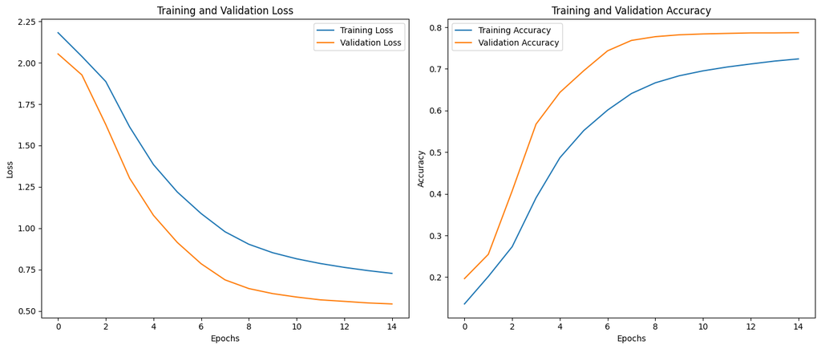

```python
# Plotting the metrics
plt.figure(figsize=(14, 6))

# Plot training and validation losses
plt.subplot(1, 2, 1)
plt.plot(training_losses, label='Training Loss')
plt.plot(validation_losses, label='Validation Loss')
plt.title('Training and Validation Loss')
plt.xlabel('Epochs')
plt.ylabel('Loss')
plt.legend()

# Plot training and validation accuracies
plt.subplot(1, 2, 2)
plt.plot(training_accuracies, label='Training Accuracy')
plt.plot(validation_accuracies, label='Validation Accuracy')
plt.title('Training and Validation Accuracy')
plt.xlabel('Epochs')
plt.ylabel('Accuracy')
plt.legend()

plt.tight_layout()
plt.show()
```

### Testing

- Loading the test data
- Preprocessing the data as done for Training
- Predicting the Missing Digits
- Storing it in the form of CSV file in required Format

```python
import pandas as pd
test=pd.read_csv(r"/content/test images concatenated_values (1).csv")
test
```

|  | Concatenated Values |
| --- | --- |
| 0 | 9027008137614000250800000706070950009106000542... |
| 1 | 0708010200207300007060920040900754800520080038... |
| 2 | 0009001650806000306022437008070950230307046009... |
| 3 | 1580096070000760027264383000359040000040800510... |
| 4 | 0020500096038002059700008361080005032060350800... |
| ... | ... |
| 9995 | 0001050300407062100009405607510943060802507040... |
| 9996 | 8058000404001300056030509170006005315060030092... |
| 9997 | 0000278000703000900489500367800000040524009783... |
| 9998 | 0020950000391800001050020980017200803275009169... |
| 9999 | 0463518299308020000109005304730900005800300800... |

10000 rows × 1 columns

```python
def preprocess_puzzle(puzzle_str):
    """
    Preprocess the input Sudoku puzzle string into a format suitable for the model.
    """
    puzzle_tensor = torch.tensor([int(p) for p in puzzle_str], dtype=torch.float32).reshape(1, 1, 9, 9) / 9 - 0.5
    return puzzle_tensor.to(device)

def predict_test_set(model, test_df):
    """
    Predict solutions for all puzzles in the test DataFrame.
    """
    model.eval()
    predictions = []

    for _, row in test_df.iterrows():
        puzzle_str = row['Concatenated Values']
        with torch.no_grad():
            puzzle_tensor = preprocess_puzzle(puzzle_str)
            output = model(puzzle_tensor)
            solution = output.argmax(dim=1).view(9, 9) + 1  # Convert predictions to 1-based indexing
            predictions.append(solution.cpu().numpy())

    return predictions
```

```python
# predict on the entire test set
predicted_solutions = predict_test_set(model, test)
```

```python
indexes = []
labels= []

for i,j in enumerate(predicted_solutions):
    preds = j.reshape(9,9)
    for row in range(0,9):
        for col in range(0,9):
            index = str(i)+"_"+str(row)+str(col)
            indexes.append(index)
            labels.append(preds[row,col])
```

```python
Test_Predictions =  {"id":indexes , "values":labels}
Test_Predictions = pd.DataFrame(Test_Predictions)
Test_Predictions
```

|  | id | values |
| --- | --- | --- |
| 0 | 0_00 | 9 |
| 1 | 0_01 | 4 |
| 2 | 0_02 | 2 |
| 3 | 0_03 | 7 |
| 4 | 0_04 | 5 |
| ... | ... | ... |
| 809995 | 9999_84 | 8 |
| 809996 | 9999_85 | 5 |
| 809997 | 9999_86 | 3 |
| 809998 | 9999_87 | 9 |
| 809999 | 9999_88 | 8 |

810000 rows × 2 columns

```python
Test_Predictions.to_csv("Test_Predictions.csv", index=False)
```